# Term-project-01-Regression-Analysis

Michael Bimal - Student Number:202389499

2025-02-21

The data set used in this project is taken from “Sample Data: Black Cherry Trees” from the Wolfram Data Repository (2016), Wolfram Research which is a sample of black cherry trees was cut down and the measurements were obtained. The purpose of collecting these data was to provide a way of predicting the volume of timber in unfelled trees, from their height and diameter measurements, using a regression model.

```r
data <- read.csv("C:\\Assignment Michael\\Cherry_Trees_data.csv")
data
```

```
##    Girth Height Volume
## 1    8.3     70   10.3
## 2    8.6     65   10.3
## 3    8.8     63   10.2
## 4   10.5     72   16.4
## 5   10.7     81   18.8
## 6   10.8     83   19.7
## 7   11.0     66   15.6
## 8   11.0     75   18.2
## 9   11.1     80   22.6
## 10  11.2     75   19.9
## 11  11.3     79   24.2
## 12  11.4     76   21.0
## 13  11.4     76   21.4
## 14  11.7     69   21.3
```

[output cut: 17 more lines]

The data set provided is already cleaned.Now i am going to do some preliminary exploratory analysis.

```r
str(data)
```

```
## 'data.frame':    31 obs. of  3 variables:
##  $ Girth : num  8.3 8.6 8.8 10.5 10.7 10.8 11 11 11.1 11.2 ...
##  $ Height: int  70 65 63 72 81 83 66 75 80 75 ...
##  $ Volume: num  10.3 10.3 10.2 16.4 18.8 19.7 15.6 18.2 22.6 19.9 ...
```

The trunk girth (in) height(ft) volume(ft3)

To decide whether we can make a predictive model, the first step is to see if there appears to a relationship between our predictor and response variables (in this case girth, height and volume).

I am going to do some exploratory data visualization.

```r
#install.packages("GGally")
library(GGally)
```

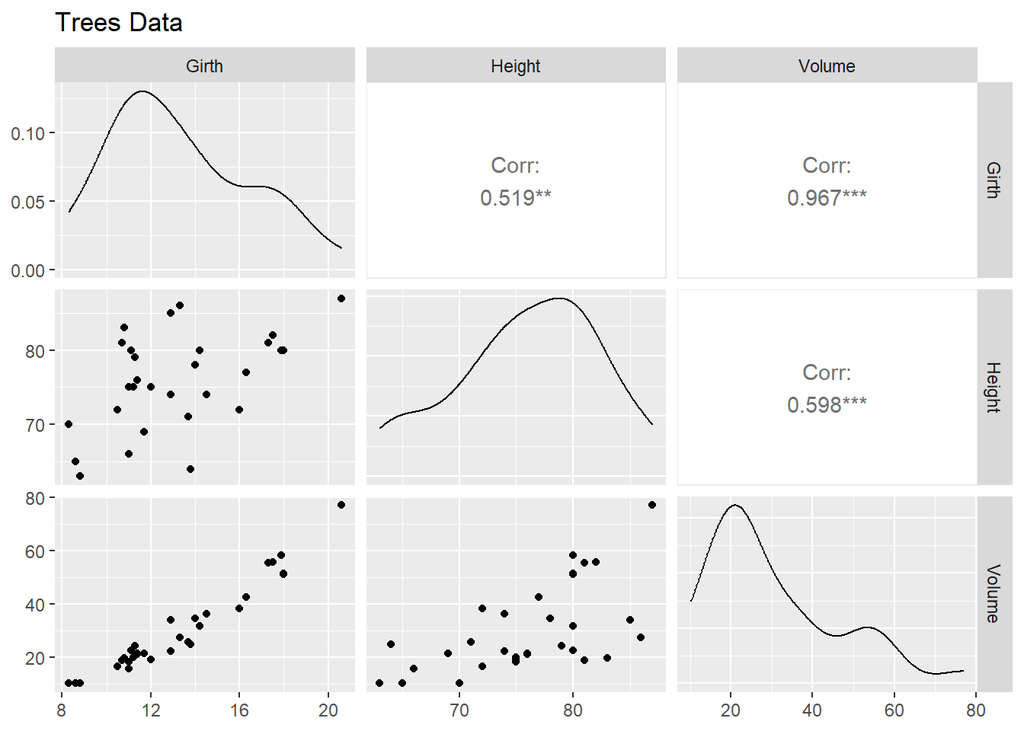

```r
ggpairs(data = data, columns = 1:3, title = "Trees Data")
```

The correlation coefficients provide information about how close the variables are to having a relationship;the closer the correlation coefficient to 1 , the stronger the relationship is . The scatter plot let us visualize the relationships between pairs of variables.

Looking at the plots , girth definitely seems to be related to volume:the correlation coefficient is close to 1, and the points seem to have a linear pattern. There may be a relationship between height and volume, but it appears to be a weaker one:the correlation coefficient is smaller, and the points in the scatter plot are more dispersed.

The relationship appears to be linear ; from the scatter plot,we can see that the tree volume increases consistently as the tree girth increases. The relationship between height and volume isn’t as clear, but the relationship between girth and volume seems strong .Now that we have a decent overall grasp of the data, we can move on to step 4 and do some predictive modeling.

Linear regression model with Girth. The linear regression describes the relationship between Volume and Girth .It helps us to separate the signal from the noise.

Forming a hypothesis: H0: There is no relationship between Girth and Volume. Ha:There is some relationship between Girth and Volume.

```r
fit_1 <- lm(Volume~Girth, data = data)
```

The lm line fits a line close to our data that is as close as possible to all 31 of our observations.More specifically , it fits the line in such a way that the sum of the squared difference between the points and the line is minimized; this method is known as “minimizing least squares”.

The model output is :

```r
summary(fit_1)
```

```
##
## Call:
## lm(formula = Volume ~ Girth, data = data)
##
## Residuals:
##    Min     1Q Median     3Q    Max
## -8.065 -3.107  0.152  3.495  9.587
##
## Coefficients:
##             Estimate Std. Error t value Pr(>|t|)
## (Intercept) -36.9435     3.3651  -10.98 7.62e-12 ***
## Girth         5.0659     0.2474   20.48  < 2e-16 ***
## ---
## Signif. codes:  0 '***' 0.001 '**' 0.01 '*' 0.05 '.' 0.1 ' ' 1
##
## Residual standard error: 4.252 on 29 degrees of freedom
## Multiple R-squared:  0.9353, Adjusted R-squared:  0.9331
## F-statistic: 419.4 on 1 and 29 DF,  p-value: < 2.2e-16
```

The intercept in our example is the expected tree volume if the value of girth was zero. The slope in our example is the effect of tree girth on tree volume.We see that for each additional inch of girth , the tree volume increases by 5.0659 ft3.The coefficient standard errors tell us the average variation of the estimated coefficients from the actual average of our response variable.

t value: This is a test statistics that measures how many standard deviation the estimated coefficients is from zero

Pr(>/t/):This number is the p-value , defined as the probability of observing any value equal or larger than t if H0 is true . The larger the t statistic, the smaller the p-value .Generally we use 0.05 as the cutoff for significance;when p-values are smaller than 0.05,we reject H0.

Making a histogram to visualize our Model Residuals

```r
#install.packages("ggplot2")
library(ggplot2)
```

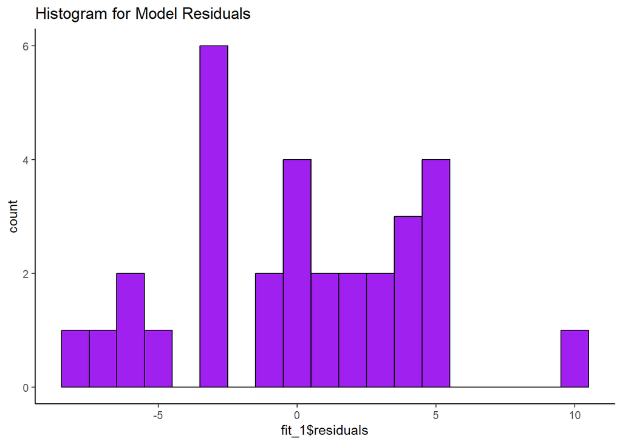

```r
ggplot( data = data, aes(fit_1$residuals)) +
  geom_histogram(binwidth = 1, color = "black", fill = "purple") +
  theme(panel.background = element_rect(fill = "white"),
        axis.line.x = element_line(),
        axis.line.y = element_line())+
    ggtitle("Histogram for Model Residuals")
```

The residuals do look symmetric around 0, suggesting that our model fits the data well.

Graph of our model

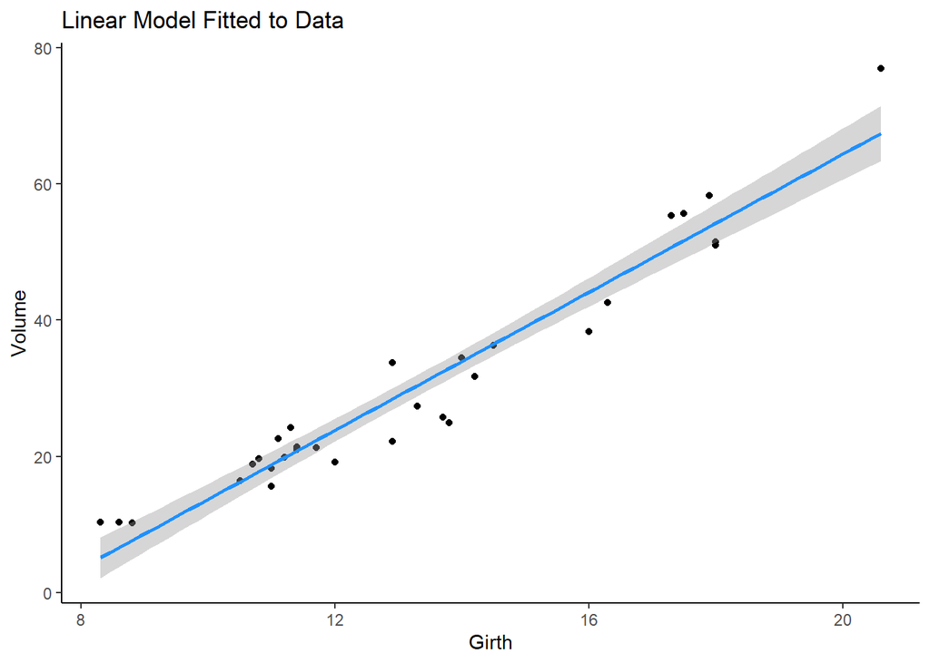

```r
ggplot(data = data, aes(x = Girth, y = Volume))+
  geom_point()+
  stat_smooth(method = "lm", col = "dodgerblue")+
  theme(panel.background = element_rect(fill ="white"),
        axis.line.x = element_line(),
        axis.line.y = element_line())+
  ggtitle("Linear Model Fitted to Data")
```

The grey shading around the line represents a confidence interval of 0.95 ,it smooths the data to make patterns easier to visualize .This 0.95 confidence interval is the probability that the true linear model for the girth and the volume of all black cherry trees will lie within the confidence interval of the regression model fitted to our data.Even though this model fits our data quite well, there is still variability within our observations.

```r
new_data <- data.frame(Girth = c(10,12,15,16,21,23),
                       Height = c(80,69,60,78,80,85))

predicted_values <- predict(fit_1, new_data)

print(predicted_values)
```

```
##        1        2        3        4        5        6
## 13.71511 23.84682 39.04439 44.11024 69.43953 79.57124
```

Multiple linear Regression

Tree Volume ≈ Intercept + Slope1(Tree Girth) + Slope2(Tree Height) + Error

```r
fit_2 <- lm(Volume ~ Girth + Height, data = data)
summary(fit_2)
```

```
##
## Call:
## lm(formula = Volume ~ Girth + Height, data = data)
##
## Residuals:
##     Min      1Q  Median      3Q     Max
## -6.4065 -2.6493 -0.2876  2.2003  8.4847
##
## Coefficients:
##             Estimate Std. Error t value Pr(>|t|)
## (Intercept) -57.9877     8.6382  -6.713 2.75e-07 ***
## Girth         4.7082     0.2643  17.816  < 2e-16 ***
## Height        0.3393     0.1302   2.607   0.0145 *
## ---
## Signif. codes:  0 '***' 0.001 '**' 0.01 '*' 0.05 '.' 0.1 ' ' 1
##
## Residual standard error: 3.882 on 28 degrees of freedom
## Multiple R-squared:  0.948,  Adjusted R-squared:  0.9442
## F-statistic:   255 on 2 and 28 DF,  p-value: < 2.2e-16
```

We can see from the model output that both girth and height are significantly related to volume, and that the model fits our data well. Our adjusted R2 value is also a little higher than our adjusted R2 for model fit_1. Since we have two predictor variables in this model, we need a third dimension to visualize it. We can create a nice 3d scatter plot using the package scatterplot3d: First, we make a grid of values for our predictor variables (within the range of our data). The expand.grid() function creates a data frame from all combinations of the factor variables.

```r
Girth <- seq(9,21, by =0.5)
Height<- seq(60,90, by =0.5)
pred_grid <- expand.grid(Girth= Girth, Height = Height)
```

Next,we make predictions for volume based on the predictor variable grid and make a 3d scatter plot from the predictor grid and the predicted volumes

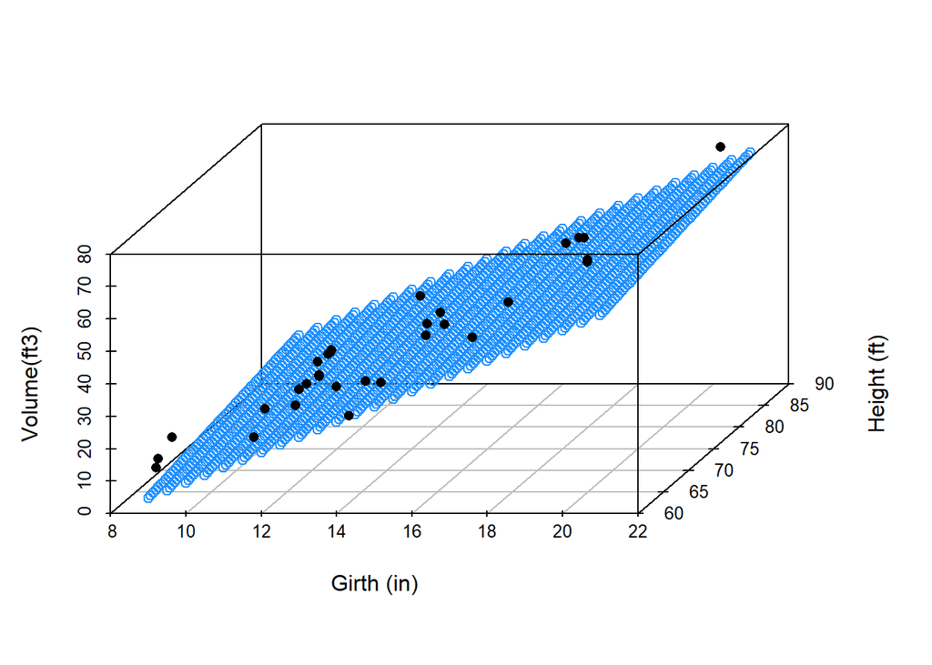

```r
#install.packages("scatterplot3d")
library(scatterplot3d)
pred_grid$Volume2 <-predict(fit_2, new = pred_grid)
fit_2_sp <- scatterplot3d(pred_grid$Girth, pred_grid$Height,pred_grid$Volume2,angle = 60, color = "dodgerblue",pch = 1, ylab = "Height (ft)", xlab = "Girth (in)", zlab = "Volume(ft3)")
fit_2_sp$points3d(data$Girth,data$Height,data$Volume, pch =16)
```

Predicting values with multiple linear regression

```r
predicted_values2 <- predict(fit_2, new_data)
predicted_values2
```

```
##        1        2        3        4        5        6
## 16.23404 21.91860 32.98982 43.80451 68.02381 79.13639
```

```r
new_data$Predicted_volume <- predicted_values2
print(new_data)
```

```
##   Girth Height Predicted_volume
## 1    10     80         16.23404
## 2    12     69         21.91860
## 3    15     60         32.98982
## 4    16     78         43.80451
## 5    21     80         68.02381
## 6    23     85         79.13639
```

Accounting for Interaction While we’ve made improvements, the model we just built still doesn’t tell the whole story. It assumes that the effect of tree girth on volume is independent from the effect of tree height on volume. This is clearly not the case, since tree height and girth are related; taller trees tend to be wider, and our exploratory data visualization indicated as much. Put another way, the slope for girth should increase as the slope for height increases. To account for this non-independence of predictor variables in our model, we can specify an interaction term, which is calculated as the product of the predictor variables.

Tree Volume ≈ Intercept + Slope1(Tree Girth) + Slope2(Tree Height) + Slope3(Tree Girth x Tree Height)+ Error

```r
fit_3 <- lm(Volume ~ Girth * Height, data = trees)
summary(fit_3)
```

```
##
## Call:
## lm(formula = Volume ~ Girth * Height, data = trees)
##
## Residuals:
##     Min      1Q  Median      3Q     Max
## -6.5821 -1.0673  0.3026  1.5641  4.6649
##
## Coefficients:
##              Estimate Std. Error t value Pr(>|t|)
## (Intercept)  69.39632   23.83575   2.911  0.00713 **
## Girth        -5.85585    1.92134  -3.048  0.00511 **
## Height       -1.29708    0.30984  -4.186  0.00027 ***
## Girth:Height  0.13465    0.02438   5.524 7.48e-06 ***
## ---
## Signif. codes:  0 '***' 0.001 '**' 0.01 '*' 0.05 '.' 0.1 ' ' 1
##
## Residual standard error: 2.709 on 27 degrees of freedom
## Multiple R-squared:  0.9756, Adjusted R-squared:  0.9728
## F-statistic: 359.3 on 3 and 27 DF,  p-value: < 2.2e-16
```

As we suspected, the interaction of girth and height is significant, suggesting that we should include the interaction term in the model we use to predict tree volume. This decision is also supported by the adjusted R2 value close to 1, the large value of F and the small value of p that suggest our model is a very good fit for the data.

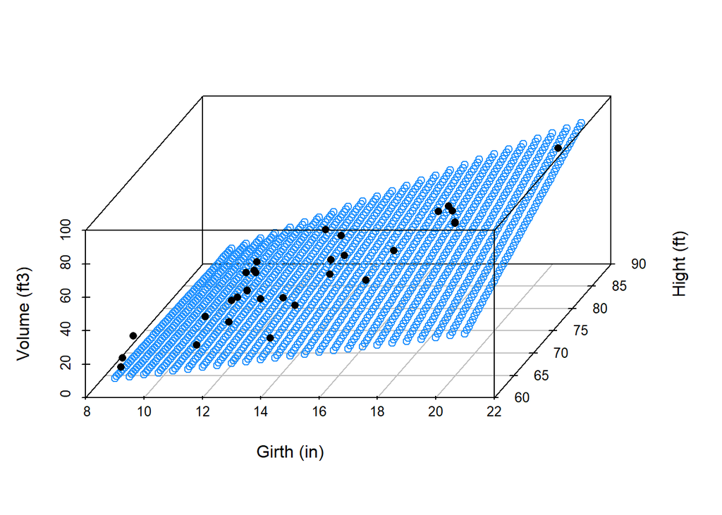

```r
Girth <- seq(9,21, by=0.5)
Height <- seq(60,90, by=0.5)
pred_grid <- expand.grid(Girth = Girth, Height = Height)
pred_grid$Volume3 <-predict(fit_3, new = pred_grid)

fit_3_sp <- scatterplot3d(pred_grid$Girth, pred_grid$Height, pred_grid$Volume3, angle = 60, color = "dodgerblue", pch = 1, ylab = "Hight (ft)", xlab = "Girth (in)", zlab = "Volume (ft3)")
fit_3_sp$points3d(trees$Girth, trees$Height, trees$Volume, pch=16)
```

It’s a little hard to see in this picture, but this time our predictions lie on some curved surface instead of a flat plane

```r
predicted_values3 <- predict(fit_3,new_data)
predicted_values3
```

```
##        1        2        3        4        5        6
## 14.79468 21.12123 24.92255 42.57893 68.87622 87.70907
```

```r
new_data$Predicted_volume <- predicted_values3
print(new_data)
```

```
##   Girth Height Predicted_volume
## 1    10     80         14.79468
## 2    12     69         21.12123
## 3    15     60         24.92255
## 4    16     78         42.57893
## 5    21     80         68.87622
## 6    23     85         87.70907
```